# 地方自治体間の子ども医療費助成競争

岩田真一郎（神奈川大学経済学部）

2023-04-2作成，2024-03-12改訂

［PDF形式：288KB］

政府は少子化対策の[たたき台](https://www8.cao.go.jp/shoushi/shoushika/meeting/outline/k_3/s1tatakidai.html)を$2023$年$3$月$31$日に公表しました．当日の日本経済新聞の記事はその要旨を紹介しています（日本経済新聞，$2023$）．その中で，子育て世帯に対する経済的支援強化策の一つとして，子ども医療費助成を行っている地方自治体に対する国民健康保険の減額調整措置を廃止する案が示されています．

子どもの医療費の負担は，未就学児が$2$割，小学生以上は$3$割が原則ですが，地方自治体は独自にそれを肩代わりして，これまで子育て世帯の負担を軽減してきました．令和$3$（$2021$年）年度[「乳幼児等に係る医療費の援助についての調査」](https://www.mhlw.go.jp/stf/newpage_28023.html)（厚生労働省）によると，市区町村レベルでは，通院は中学生まで，入院は高校生まで助成する自治体が多かったようです．厚生労働省は過剰受診を招く可能性を考慮して，このような医療費助成を行っている地方自治体に対して国民健康保険への補助金を減額する措置をとってきたのです（$\rm{NHK}$，$2023$）．[^1]

# 1 地方自治体間住民獲得競争

なぜ地方自治体は厚生労働省の減額措置を受けてまで子ども医療費助成を充実させてきたのでしょうか？その理由として，地方自治体間の住民獲得競争があげられます（上月，$2023$；日本経済新聞，$2018$）．他の地方自治体が子育て世帯を引きつけるような転入政策をとると，自分の街から子育て世帯が転出してしまうかもしれません．そこで，各地方自治体は，他の地方自治体と同様に子育て世帯を引きつけるような対抗策をとることになります．このように，地方自治体の政策は横並びになる傾向があります（上月，$2023$）．

地方自治体の横並び意識は空間的距離が近い箇所で強くなることは想像しやすいでしょう（$\rm{Brueckner}$，$2003$）．実際に，日本経済新聞（$2018$）の文面からもその様子がうかがえます．記事では，神奈川県相模原市が$2018$年$10$月に，それまで小学生までとしていた助成対象を中学生まで引き上げることが記されています．その理由として，図$1$に示されるように隣接する東京都町田市や神奈川県大和市の助成対象が中学生までであることがあげられています．記事では，「一つの自治体が助成を拡充すると，ドミノ式に**周辺に波及する**傾向にある」ことも指摘されています．

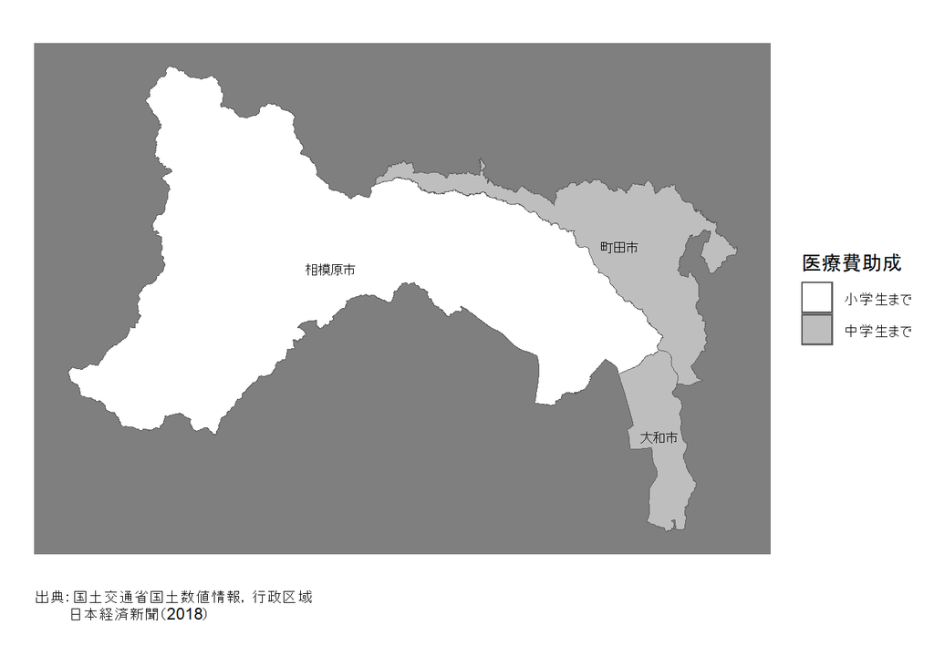

図1：2018年度の医療費助成状況

# 2 囚人のジレンマ

隣接する地方自治体の政策が横並びになるのであれば，住民獲得競争の効果は削減するはずです．地方自治体の政策が国の定めた原則ルールにとどまれないのはなぜでしょうか？それは，各地方自治体が自分の街のことしか考えないからです．このことを**ゲーム理論**を使って説明しましょう．

そこで，隣接する二つの地方自治体$\rm{A}$市と$\rm{B}$市の医療費助成政策を考えます．二つの地方自治体は医療費助成として二つの選択肢（これを**戦略**とよびます）「小学生まで」と「中学生まで」の中から一つを選ぶとします．各地方自治体は選択する戦略に応じて利益を得ます．この利益をゲーム理論では**利得**とよびます．ここでは，医療費助成によって街に子育て世帯が増えることで利得が増加すると考えます．[^2]一方，その対価として財政（医療費）負担が増加し，利得が減少すると考えます．利得は，各地方自治体が選ぶ戦略だけではなく，もう一方の地方自治体が選ぶ戦略にも依存します．すなわち，各地方自治体の利得は以下の四つの戦略の組み合わせ

- $A$市が「小学生まで」，$B$市も「小学生まで」医療費助成
- $A$市が「小学生まで」，$B$市は「中学生まで」医療費助成
- $A$市が「中学生まで」，$B$市は「小学生まで」医療費助成
- $A$市が「中学生まで」，$B$市も「中学生まで」医療費助成

に応じて決まることになります．

それでは，この四つの戦略の組み合わせから最終的にどの組み合わせが選ばれるでしょうか？このことを分析するために考えられたのが表$1$の**利得表**なります．利得表には，**プレーヤー**（今回の例では$A$市と$B$市になります），プレーヤーの取り得る戦略，戦略と利得の関係がまとめまられています．表$1$では，括弧内の左の数値が$A$市の利得，右の数値が$B$市の利得を表しています．

表1：利得表

|  |  | B市 |  |
| --- | --- | --- | --- |
|  |  | 小学生まで | 中学生まで |
| A市 | 小学生まで | （40, 40） | （30, 50） |
|  | 中学生まで | （50, 30） | （35, 35） |

表の括弧内の数値は左がA市の利得，右がB市の利得を示す

仮に$B$市が「小学生まで」を選んだとしましょう．このとき，$A$市は「小学生まで」を選択すると，利得は$40$になります．一方，「中学生まで」を選択すると，利得を減少させる効果（財政負担の増加）の絶対値よりも，増加させる効果（子育て世帯の$A$市への転入）が上回り，利得が$50$に増加します．したがって，$B$市が「小学生まで」を選んだ場合，$A$市は「中学生まで」を選択することになります．（このとき，大きい利得の値に下線を引くと，最終的にどの戦略の組み合わせが選ばれるかわかりやすくなりますので，可能な場合，$50$に下線を引いておきましょう．参考までに，下線を引いた表は次のようになります．）

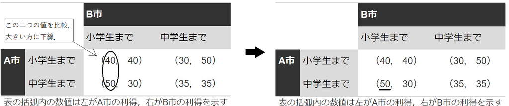

次に，仮に$B$市が「中学生まで」を選んだ場合の$A$市が選ぶ戦略を考えてみましょう．$A$市は「小学生まで」を選択すると，利得は$30$に減少します．これは，利得を減少させる効果（子育て世帯の$B$市への転出）の絶対値が，増加させる効果（財政負担の軽減）を上回るからです．「中学生まで」を選択すると，利得は$35$まで回復します．したがって，$B$市が「中学生まで」を選んだ場合，$A$市は利得が大きくなる「中学生まで」を選択することになります（$35$に下線を引きます）．

これまでの分析から，$A$市は$B$市が選ぶ戦略に関わらず「中学生まで」を選びます．このように，あるプレーヤーにとって，他のプレーヤーがどのような戦略をとろうとも，つねに利得が高くなる戦略が存在する場合，その戦略を**支配戦略**とよびます．

同様に，$B$市について考えましょう．表$1$から$B$市の利得は$A$市と対称的であることがわかります．したがって，$B$市にとっても「中学生まで」が支配戦略になります（$A$市が「小学生まで」を選んだ場合は$50$に下線を，$A$市が「中学生まで」を選んだ場合は$35$に下線を引きましょう）．

以上から，最終的に選ばれる戦略の組み合わせは表$2$の背景が灰色，数字が太字の部分になります（利得に下線を引いている場合は，どちらの利得にも下線が引かれているはずです）．すなわち，

- $A$市が「中学生まで」，$B$市も「中学生まで」医療費助成

という戦略の組み合わせです．この戦略の組み合わせがこのゲームの**ナッシュ均衡**になります．ナッシュ均衡の下では，各プレーヤーは自分だけが戦略を変更することによって利得を増やすことはできません．

表2：ナッシュ均衡

|  |  | B市 |  |
| --- | --- | --- | --- |
|  |  | 小学生まで | 中学生まで |
| A市 | 小学生まで | （40, 40） | （30, 50） |
|  | 中学生まで | （50, 30） | （35, 35） |

表の括弧内の数値は左がA市の利得，右がB市の利得を示す

このゲームの興味深いところは，双方が「小学生まで」を選んだ方が利得が高くなる（$40$の利得）にも関わらず，双方とも「中学生まで」を選んでしまうことです．繰り返しになりますが，これは各地方自治体が自分の利得のことしか考えないため，相手が「小学生まで」を選んだ場合に，「中学生まで」を選んでしまうことが原因です．双方が横並びの「中学生まで」を選ぶ結果，住民の移動は起こらず，財政（医療費）負担だけがのしかかり，利得（$35$）が減少します．ゲーム理論では，このような状況を**囚人のジレンマ**と例えます．[^3]

冒頭でも述べたように，政府は地方自治体が独自に行っている子ども医療費助成を容認する方向で検討に入っています．このことは，地方財政を疲弊させる地方自治体間の子ども医療費助成競争を助長することを意味します．現在（$2023$年$4$月），通院費を「高校生まで」助成する地方自治体が増加傾向にあるようです（上月，$2023$）．今後，「高校生まで」医療費助成する地方自治体が支配的になるかもしれません．

# 参考文献

- 上月直之（$2023$）[「広がる子供の医療費無料化，過剰受診も 見直しは進まず」](https://www.nikkei.com/article/DGXZQOCC151XJ0V10C23A1000000/)『日本経済新聞』$2023$年$2$月$19$日（健康・医療）
- $\rm{NHK}$ （$2023$）[「子ども医療費助成の自治体への補助金減 取りやめの方向で検討」](https://www3.nhk.or.jp/news/html/20230324/k10014019181000.html)$2023$年$3$月$24$日（社会ニュース一覧）
- 日本経済新聞（$2018$）[「子ども医療費助成どこまで（上）：高校生まで対象 $3$割 負担減競争エスカレート」](https://www.nikkei.com/article/DGKKZO33047950X10C18A7EE8000/)『日本経済新聞』$2018$年$7$月$18$日
- 日本経済新聞（$2023$）[「児童手当見直しも 政府の少子化対策「たたき台」要旨」](https://www.nikkei.com/article/DGXZQOUA306LD0Q3A330C2000000/)『日本経済新聞』$2023$年$3$月$31$日（経済）
- $\rm{Brueckner}$, $\rm{J. K.}$ ($2003$) [$\rm{Strategic}$ $\rm{interaction}$ $\rm{among}$ $\rm{governments:}$ $\rm{An}$ $\rm{overview}$ $\rm{of}$ $\rm{empirical}$ $\rm{studies,}$](https://journals.sagepub.com/doi/abs/10.1177/0160017602250974?journalCode=irxa) $\rm{International}$ $\rm{Regional}$ $\rm{Science}$ $\rm{Review}$, $26 (2)$, $175-188$.

# R環境

**セッション情報**

- R version 4.1.3 (2022-03-10)
  - RStudio 2022.07.1+554
  - rmarkdown_2.19

**使用したパッケージ**

- `gt`
- `sf`
- `tidyverse`

# リンク

- [都市経済学講義ノート](https://shinichiro-iwata.github.io/lecture-notes-urban-econ/)
- [Rによる地理空間データの可視化](https://shinichiro-iwata.github.io/geospatial-data-visualization/)
- [Shinichiro Iwata](https://shinichiro-iwata.github.io/)

**アイコン**

- Font Awesome 6.3.0
[^1]: 上月（$2023$）は経済学者による過剰受診の研究成果を日本経済新聞上で紹介しています．
[^2]: 実際には病気やけがから回復する子どもが増えることで地方自治体の利得が高まることも期待されているかもしれませんが，ここでは考えません．
[^3]: 警察に捕まった二人の共犯者が，別々の取調室で沈黙を保てば刑が軽くなるにも関わらず，自分だけが告白すると刑が軽くなる誘因が与えられるため，結果的に二人とも告白してしまい，重い刑が科せられる状況を囚人のジレンマとよびます．